# Inference

# Reminders

- You should have received an email about signing up for the GVPT experimental lab
- Check the exam 1 module for [a list of things to know for exam 1](https://umd.instructure.com/courses/1380001/files/82916912?module_item_id=13515594). Be ready to ask about them on Monday.

# For today

- We’ll start on introducing material from chapter 6. This will not be on the upcoming midterm, but we’ll revisit it after the break
- We’ll talk about some math, but ultimately we don’t need a lot beyond square roots to understand what’s going on. The more important part is the intuition.

# How do we calculate a margin of error for a survey?

# Margin of error and surveys

Note: the general principles here apply to analyses of non-survey data as well, but we’ll talk in terms of surveys because that tends to be a bit more familiar for people (or at least gov majors)

# Sampling

Remember that:

- **We want to talk about the population**: the beliefs and behaviors of all eligible voters, or all countries, or all adults. We’ll call characteristics of this group (mean, standard deviation, median etc) **population parameters**
- But we typically only have data on a **sample** from the population. We’ll call characteristics of this group **sample statistics**

# Sampling

We don’t expect the a sample mean to exactly equal a population mean. But we expect it to have some random error.

Sample Statistic = Population Parameter $\pm$ Random Error

We don’t know the actual size of the error for a given statistic, but we can estimate the probability of an error greater than some value.

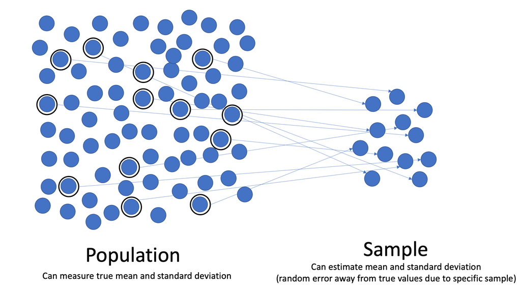

from: Wikimedia Commons https://commons.wikimedia.org/wiki/File:Population_versus_sample_%28statistics%29.png

## Uncertainty and sampling

The general intuition:

- **more data = more certainty.** Estimates from a really big representative sample are going to be more likely to approximate the true population mean.
- **less variance = more certainty.** If people in the target population are pretty much the same, then it is more likely that a given sample will resemble the target population.

## Margin of error

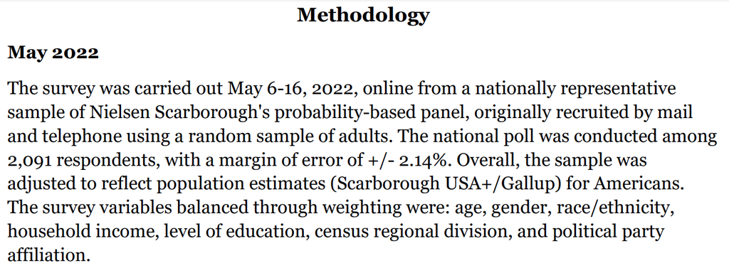

from https://criticalissues.umd.edu/feature/new-study-change-us-public-attitudes-towards-jews-and-muslims-2022-2024

## Margin of error

- The margin of error is more frequently called a “confidence interval” in statistics.
- A confidence interval is a range that we are reasonably certain contains the actual population value.
  - Specifically, the margin generally reported in a survey is a 95% confidence interval when there’s a 50/50 split in a dichotomous outcome.
  - If I estimate that 50% of respondents are Democrats with a margin of error of +/- 3% then I’m saying I’m 95% certain that the range 47-53% contains the true population % of Dems.

## Margin of error = Confidence Interval

95% confidence means: “if I repeated this survey an infinite number of times and recalculated the CI for each one, 95% of my calculated confidence intervals would contain the actual population value.”

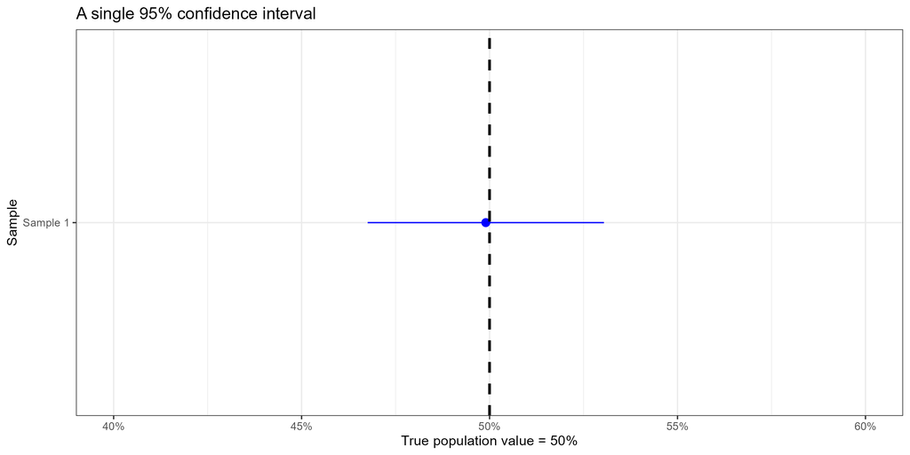

## Margin of error = Confidence Interval

We generally aren’t bothering to sample anything repeatedly, so how do we know this?

The main reason we’re able to calculate a confidence interval is because we actually know a lot about how random errors “behave” in repeated sampling thanks to the central limit theorem.

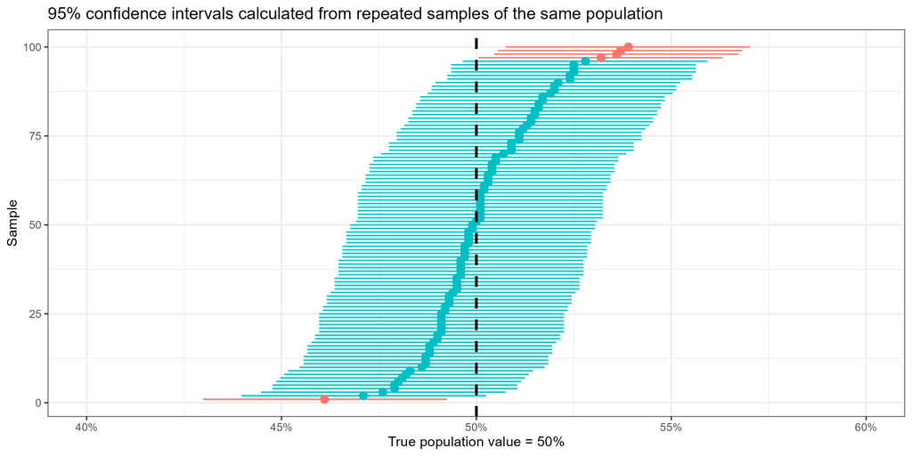

# The Central Limit Theorem

**Central Limit Theorem**

As the number of repeated samples approaches infinity, the **sampling distribution** of the sample mean will converge toward a normal distribution centered on the population mean.

# Sampling distribution

## Coin flips

Think about flipping a coin:

- the probability of landing on heads is 50% (this is our population parameter)
- We’ll run an “experiment” where we flip a coin 50 times and calculate the proportion of heads.
  - (remember that, for a dummy (0, 1) coded dichotomous outcome, the proportion = the mean)

## Coin flips

This is hardly surprising!

```r
# simulating flipping 50 coins:
coinflips <- sample(c("heads","tails"), size=50, replace=TRUE)
# counting the number of heads
prop_heads<-mean(coinflips=='heads')
```

```
the proportion of heads is 0.38.
The error is .5 - 0.38 = -0.12
```

I get closer to the correct answer when I increase the sample size, but I still will have some amount of error:

```r
# simulating flipping 50 coins:
coinflips <- sample(c("heads","tails"), size=500, replace=TRUE)
# counting the number of heads
prop_heads <- mean(coinflips=='heads')
```

```
the proportion of heads is 0.51.
The error is .5 - 0.51 = 0.01
```

## The sampling distribution of coin flips

Repeating this experiment 5,000 times will give us a sense of the **sampling distribution** for this sample statistic:

```r
# 5000 "samples" of the coin-flipping experiment
trials<-replicate(5000, sample(c("heads","tails"), size=50, replace=TRUE)=="heads")
# get the average num of heads in each trial. Expected value = .5
mean_heads <- colMeans(trials)
# draw a histogram
hist(mean_heads, main ='proportion of heads in 50 coin flips', breaks=30)
```

we should get a distribution that looks like this:

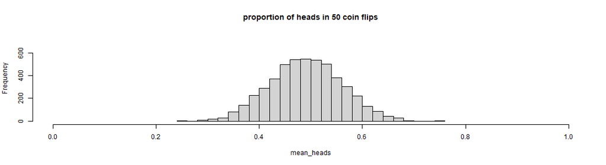

## The sampling distribution of coin flips

- The samples are centered around the expected proportion of .5 heads
- More extreme errors are less common than small ones
- The results are symmetric: there are about as many high values as low ones.
- Error = Sample Mean - Population Mean, so the distribution of errors has this same shape, but its centered around zero.

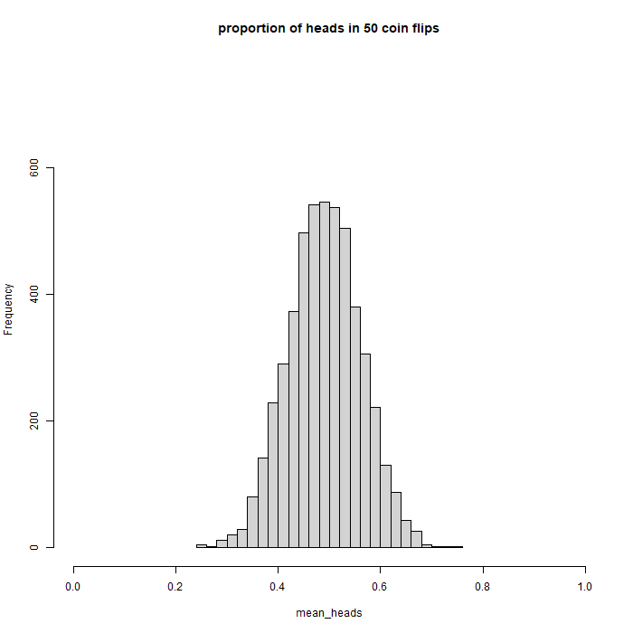

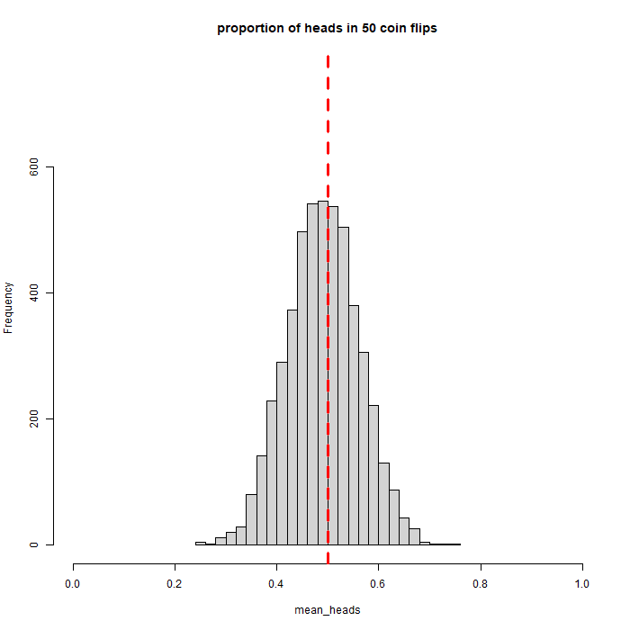

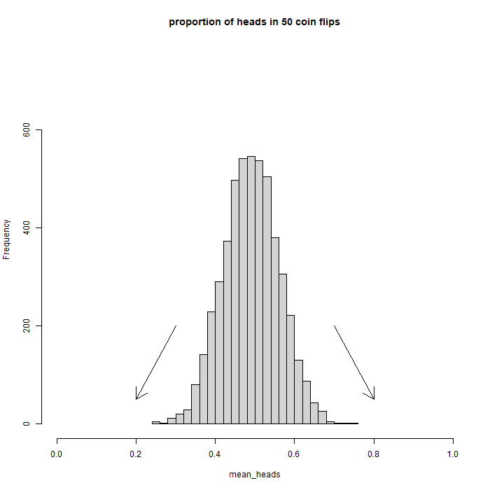

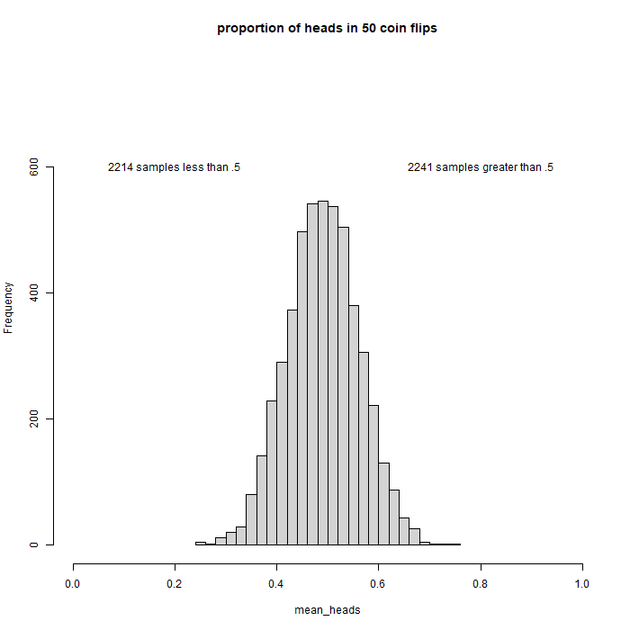

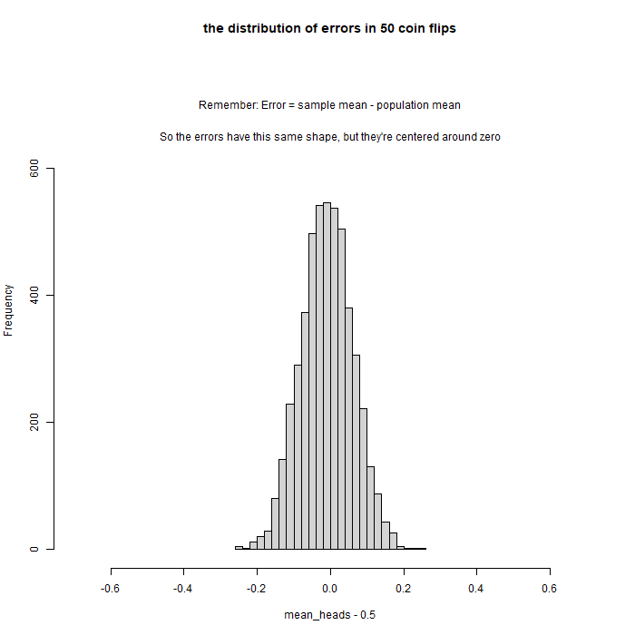

## The sampling distribution of coin flips

Coin flips technically follow a binomial distribution but our sampling distribution looks a lot like a normal “bell-curve” centered on .5

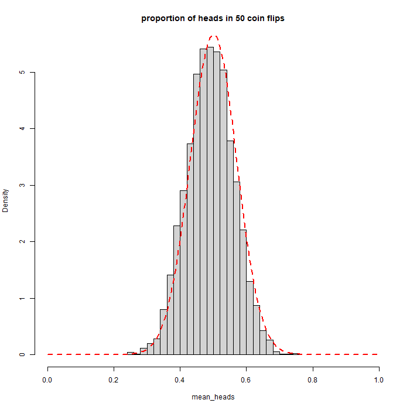

## Sampling distributions of sample means

In fact, for a sufficient sample size, sampling distributions of sample means will **always** end up looking like this regardless of the actual population distribution.

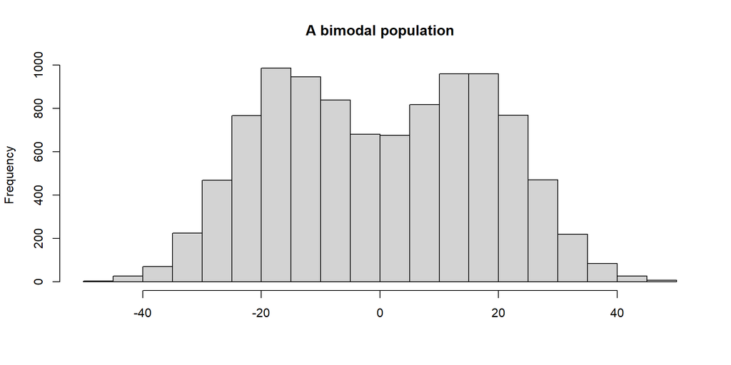

[figure not shown]

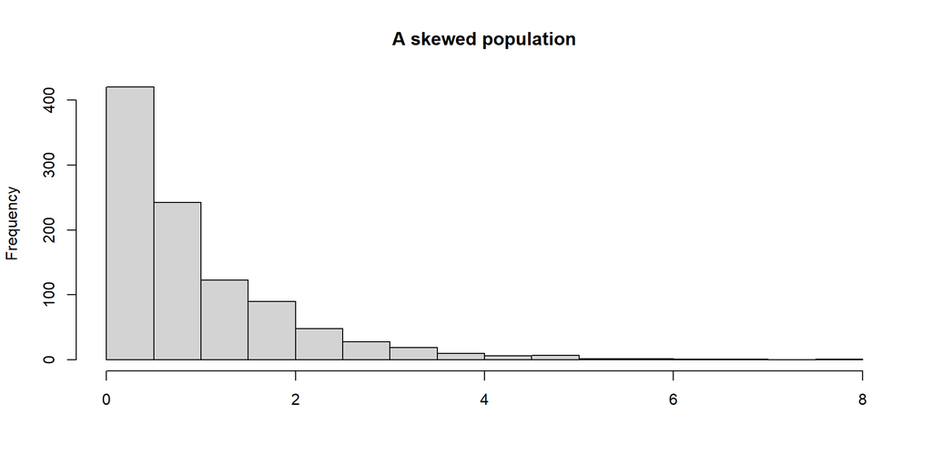

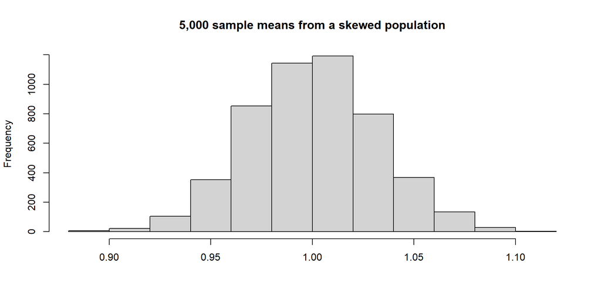

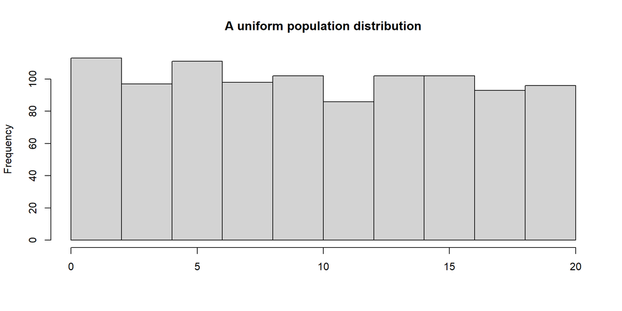

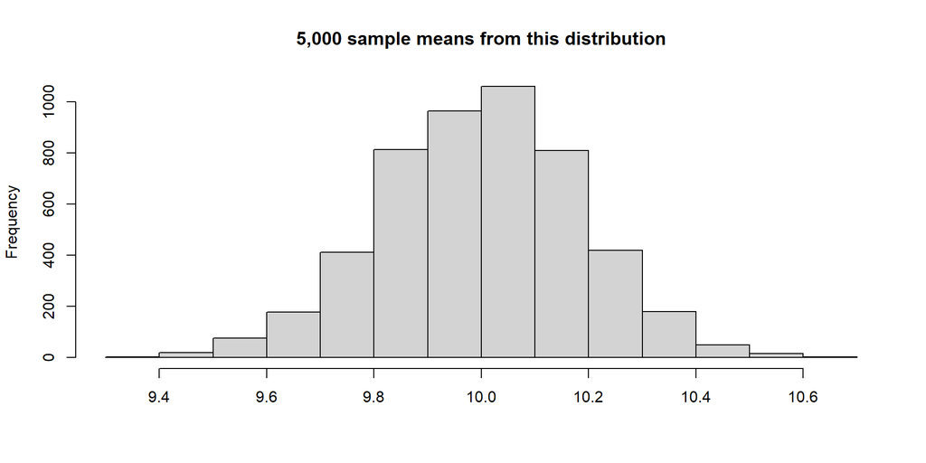

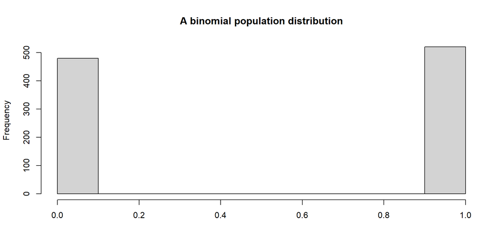

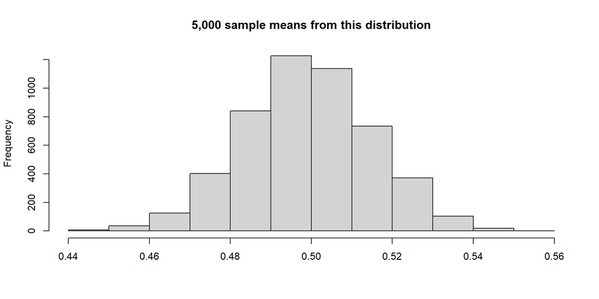

## The normal distribution

We know a lot about bell curves. If we have mean $\mu$ and a standard deviation $\sigma$, we can easily find how much data we expect to fall anywhere within this shape using the probability density function.

$$f(x) = \frac{1}{\sigma\sqrt{2\pi}}
\exp\left( -\frac{1}{2}\left(\frac{x-\mu}{\sigma}\right)^{\!2}\,\right)$$

(Maybe not the kind of thing you want to calculate in your head, but pretty easy for a computer)

## The normal distribution

```r
mu<-0
sigma<-1

curve((1 / (sqrt(2*pi) * sigma)) * exp(-(x - mu)^2 / (2 * sigma^2)), from=-3, to=3,
      xlab = '',
      main = 'PDF of a normal with mean = 0 and sigma = 1'
      )
```

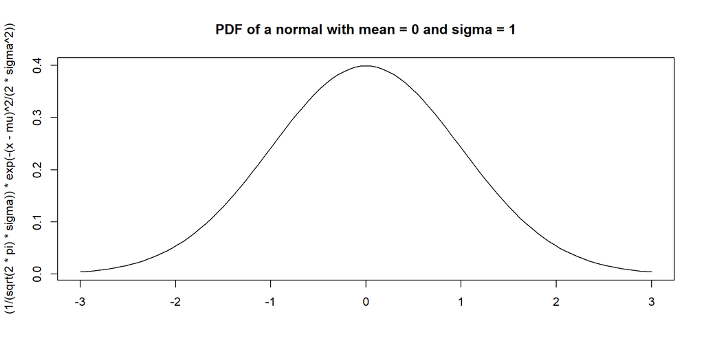

## The normal distribution

The mean ($\mu$) and standard deviation $\sigma$ will depend on the data, but we can always:

1. Mean center: subtract the mean $\mu$ from each observation so that the new mean is zero.
2. Standardize: divide each observation by the standard deviation of the sampling distribution ($\sigma$), so the new standard deviation is 1

We’ll call this new number the “Z-score”:

$$\text{Z score} = \frac{\text{Deviation from the mean}}{\text{Standard Deviation}}$$

## The Standard Normal Distribution (or Z distribution)

Once we standardize our data to a Z-score, then:

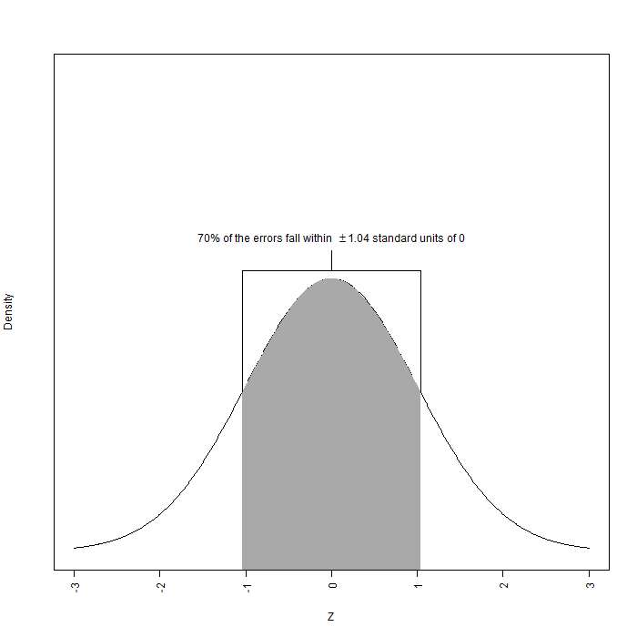

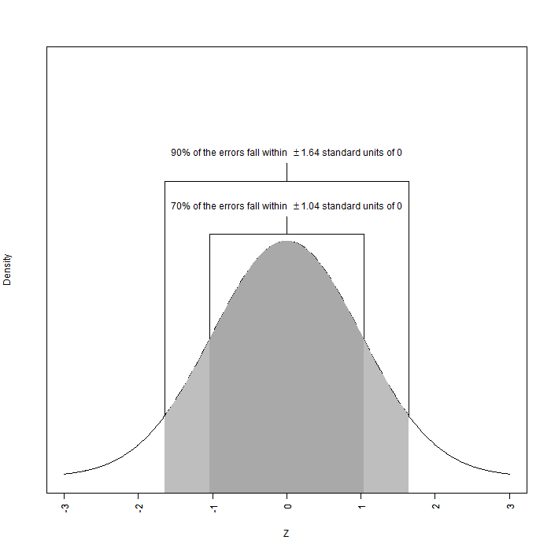

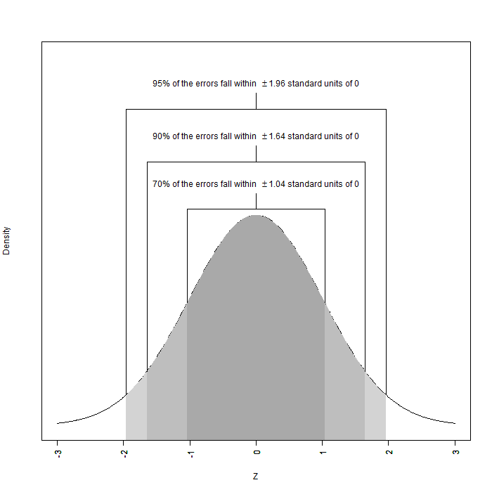

## The Central Limit Theorem

**Central Limit Theorem**

As the number of repeated samples approaches infinity, the sampling distribution of the mean will converge toward a normal distribution centered on the population mean.

This means that:

- The sampling errors will also have a normal distribution centered on zero.
- Sampling errors/means are normally distributed even if the population is non-normal.
- We can calculate the proportion of data that falls under different parts of the curve, provided we know $\mu$ and $\sigma$

# So what?

## Using the CLT

We don’t need to take infinite samples to make use of this! We can draw a sample and assume that it comes from a distribution with this shape:

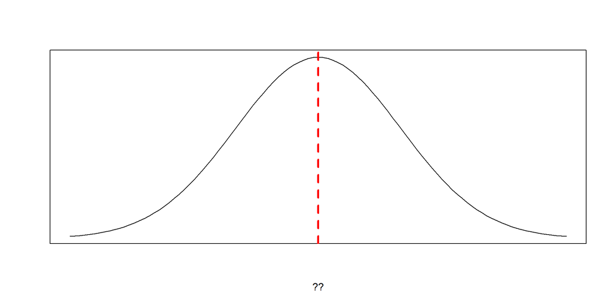

## Using the CLT

$$f(x) = \frac{1}{\color{red}{\sigma}\sqrt{2\pi}}
\exp\left( -\frac{1}{2}\left(\frac{x-\color{red}{\mu}}{\color{red}{\sigma}}\right)^{\!2}\,\right)$$

Remember: we need to know $\mu$ and $\sigma$

- We don’t know our population mean $\mu$, but we do know that the mean sampling error is zero, so we can just use 0 our expected mean error.
- However, we still need to know the standard deviation $\sigma$
  - Here, we’re looking for **the standard deviation of the sampling errors**. We’ll call this value our standard error or SE for short.
  - Finding this is a challenge, but we can make some simple assumptions here to get a “worst case scenario” for a survey

## The standard error

Remember that more observations = more certainty. So we expect that the standard error will decrease when taking larger samples.

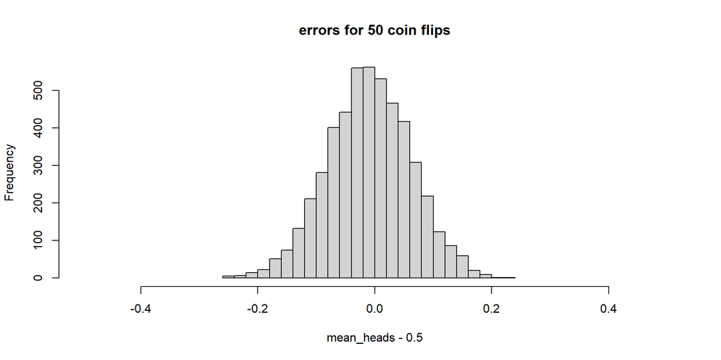

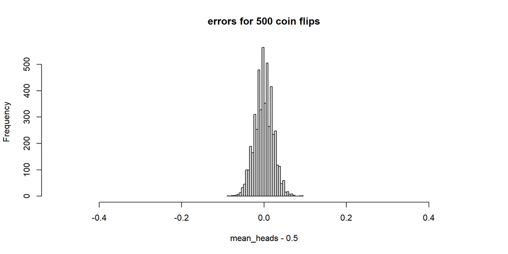

We actually know how much the SE shrinks for each observation:

$$\text{Standard error (SE)} = \frac{\sigma}{\sqrt{n}}$$

## The standard error of a proportion

$$\text{Standard error (SE)} = \frac{\sigma}{\sqrt{n}}$$

We don’t know $\sigma$, but surveys are usually reporting a proportion or percentage of people giving a particular response. The standard error of a proportion actually depends on the proportion itself:

$$\text{Standard Error of a proportion} = \frac{\sqrt{p\times(1-p)}}{\sqrt{n}} = \sqrt{\frac{p\times(1-p)}{n}}$$

$$p = \text{the proportion}$$

## The standard error of a proportion

Note that this part of the formula is at its maximum when p = .5 (i.e. when there’s a 50/50 split on a yes/no question)

$$\text{Standard Error of a proportion} = \sqrt{\frac{\color{red}{p\times(1-p)}}{n}}$$

So, if we know our sample size, we can calculate the worst case scenario for the standard error where $p = .5$

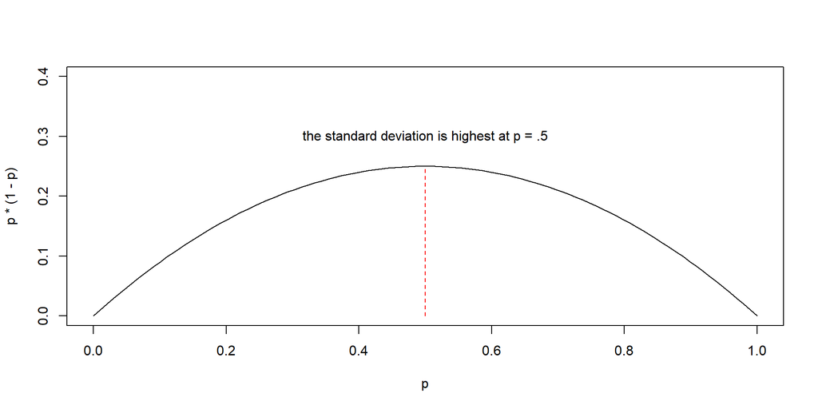

## Back to that margin

- We know our sample size is 2,091
- We know that the biggest SE possible is when $p = .5$, $\sqrt{\frac{.5(1-.5)}{n}}$, so the worst case scenario is $\sqrt{\frac{.5(1-.5)}{2,091}} \approx 0.0109$
- We also know that the **errors** are normally distributed and centered around 0

We have all the ingredients to we need to apply the CLT here!

## The Margin of error

Remember we want a 95% confidence level.

We already know that for this pdf, 95% of the errors will fall with in approximately $\pm 2 \times Z$ of 0 (technically closer to 1.95994…)

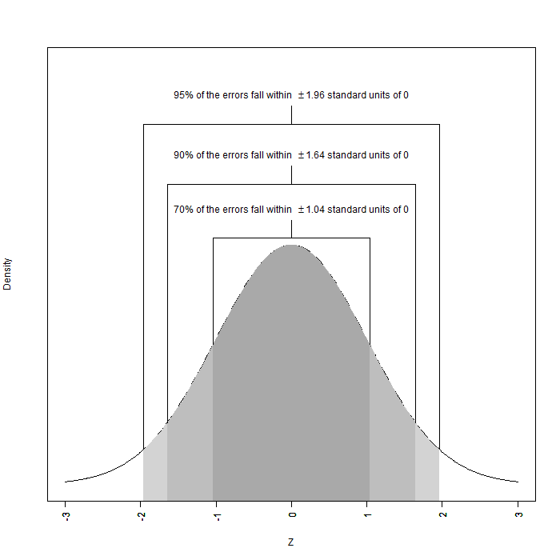

## The Margin of error

$$\text{Standard Error of a proportion} = \sqrt{\frac{p\times(1-p)}{n}}$$

$$\text{SE for this sample at (p=0.5)} = \sqrt{\frac{.5(1-.5)}{2,091}} \approx 0.0109$$

So now we just need:

$$\text{standard error} \times \text{Z-score for a 95% confidence level}$$

$$.0109 \times 1.96 \approx 0.0214 = 2.14\%$$

## The Margin of error

So what is the margin of error on a poll?

Its a 95% confidence interval for a worst case scenario where there’s a 50/50 split on a question with two response categories.

# Next questions:

- The margin of error is a worst case scenario. Its convenient to have one number that can apply to the entire survey, but we can generally be more precise with our confidence intervals.
- We often want to estimate confidence for things that aren’t proportions, so how do we do this without knowing the population value for $\sigma$?